# Descripción del proyecto

Film Junky Union, una nueva comunidad vanguardista para los aficionados de las películas clásicas, está desarrollando un sistema para filtrar y categorizar reseñas de películas. Tu objetivo es entrenar un modelo para detectar las críticas negativas de forma automática. Para lograrlo, utilizarás un conjunto de datos de reseñas de películas de IMDB con leyendas de polaridad para construir un modelo para clasificar las reseñas positivas y negativas. Este deberá alcanzar un valor F1 de al menos 0.85.

# Tabla de contenidos

## Inicialización

```python
import math

import numpy as np
import pandas as pd

import matplotlib
import matplotlib.pyplot as plt
import matplotlib.dates as mdates
import seaborn as sns

from tqdm.auto import tqdm

# ocultar warnings
import warnings
warnings.filterwarnings('ignore')
```

```python
%matplotlib inline
%config InlineBackend.figure_format = 'png'
# la siguiente línea proporciona gráficos de mejor calidad en pantallas HiDPI
# %config InlineBackend.figure_format = 'retina'

plt.style.use('seaborn')
```

```python
# esto es para usar progress_apply, puedes leer más en https://pypi.org/project/tqdm/#pandas-integration
tqdm.pandas()
```

## Cargar datos

```python
df_reviews = pd.read_csv('/datasets/imdb_reviews.tsv', sep='\t', dtype={'votes': 'Int64'})
df_reviews.info()
```

```
<class 'pandas.core.frame.DataFrame'>
RangeIndex: 47331 entries, 0 to 47330
Data columns (total 17 columns):
 #   Column           Non-Null Count  Dtype
---  ------           --------------  -----
 0   tconst           47331 non-null  object
 1   title_type       47331 non-null  object
 2   primary_title    47331 non-null  object
 3   original_title   47331 non-null  object
 4   start_year       47331 non-null  int64
 5   end_year         47331 non-null  object
 6   runtime_minutes  47331 non-null  object
 7   is_adult         47331 non-null  int64
 8   genres           47331 non-null  object
 9   average_rating   47329 non-null  float64
 10  votes            47329 non-null  Int64
 11  review           47331 non-null  object
 12  rating           47331 non-null  int64
 13  sp               47331 non-null  object
 14  pos              47331 non-null  int64
 15  ds_part          47331 non-null  object
 16  idx              47331 non-null  int64
dtypes: Int64(1), float64(1), int64(5), object(10)
memory usage: 6.2+ MB
```

## EDA (Exploratory Data Analysis)

### Analisis del dataset en general

En esta sección hare un breve analisis exploratorio de los datos. Veamos el número de películas y reseñas a lo largo de los años.

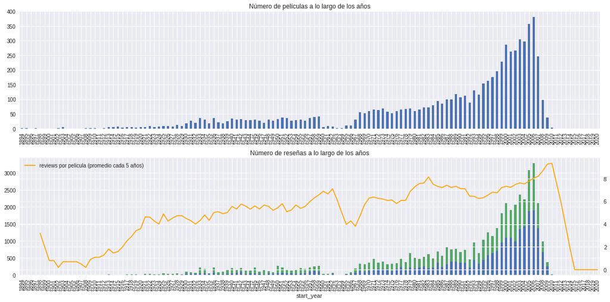

```python
fig, axs = plt.subplots(2, 1, figsize=(16, 8))

ax = axs[0]

dft1 = df_reviews[['tconst', 'start_year']].drop_duplicates() \
    ['start_year'].value_counts().sort_index()
dft1 = dft1.reindex(index=np.arange(dft1.index.min(), max(dft1.index.max(), 2021))).fillna(0)
dft1.plot(kind='bar', ax=ax)
ax.set_title('Número de películas a lo largo de los años')

ax = axs[1]

dft2 = df_reviews.groupby(['start_year', 'pos'])['pos'].count().unstack()
dft2 = dft2.reindex(index=np.arange(dft2.index.min(), max(dft2.index.max(), 2021))).fillna(0)

dft2.plot(kind='bar', stacked=True, label='#reviews (neg, pos)', ax=ax)

dft2 = df_reviews['start_year'].value_counts().sort_index()
dft2 = dft2.reindex(index=np.arange(dft2.index.min(), max(dft2.index.max(), 2021))).fillna(0)
dft3 = (dft2/dft1).fillna(0)
axt = ax.twinx()
dft3.reset_index(drop=True).rolling(5).mean().plot(color='orange', label='reviews por pelicula (promedio cada 5 años)', ax=axt)

lines, labels = axt.get_legend_handles_labels()
ax.legend(lines, labels, loc='upper left')

ax.set_title('Número de reseñas a lo largo de los años')

fig.tight_layout()
```

Nuestro dataset dispone de una columna llamada `ds_part` la cual especifica la información qué debe ser usada tanto como entrenamiento y prueba para nuestros modelos. Veamos rápidamente la distribución de calificaciones para cada grupo.

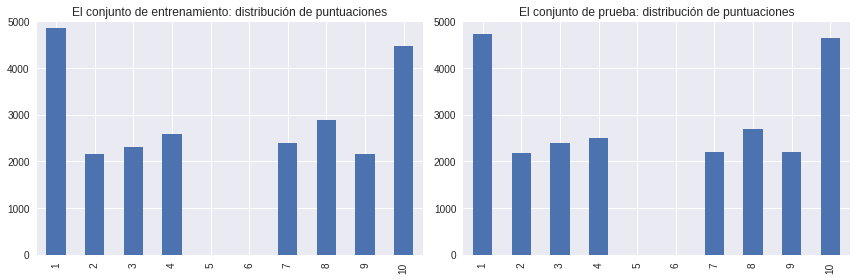

```python
fig, axs = plt.subplots(1, 2, figsize=(12, 4))

ax = axs[0]
dft = df_reviews.query('ds_part == "train"')['rating'].value_counts().sort_index()
dft = dft.reindex(index=np.arange(min(dft.index.min(), 1), max(dft.index.max(), 11))).fillna(0)
dft.plot.bar(ax=ax)
ax.set_ylim([0, 5000])
ax.set_title('El conjunto de entrenamiento: distribución de puntuaciones')

ax = axs[1]
dft = df_reviews.query('ds_part == "test"')['rating'].value_counts().sort_index()
dft = dft.reindex(index=np.arange(min(dft.index.min(), 1), max(dft.index.max(), 11))).fillna(0)
dft.plot.bar(ax=ax)
ax.set_ylim([0, 5000])
ax.set_title('El conjunto de prueba: distribución de puntuaciones')

fig.tight_layout()
```

En general, tanto el grupo de entrenamiento como de prueba tienen distribuciones de puntuanciones similares.

### Analisis de las variables de interes

Si bien, el dataset proporcionado posee mucha información de peliculas a lo largo de los años, para este estudio en particular, solo nos interesan las siguientes columnas:

`review`: el texto de la reseña  
`pos`: el objetivo, '0' para negativo y '1' para positivo  
`ds_part`: 'entrenamiento'/'prueba' para la parte de entrenamiento/prueba del conjunto de datos, respectivamente

Dicho esto, ahora compararemos la distribución de la columna `pos` tanto para nuestros grupo de entrenamiento, como el de prueba.

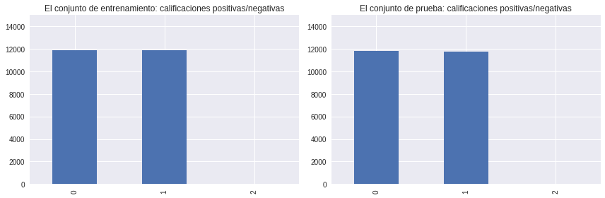

```python
fig, axs = plt.subplots(1, 2, figsize=(12, 4))

ax = axs[0]
dft = df_reviews.query('ds_part == "train"')['pos'].value_counts().sort_index()
dft = dft.reindex(index=np.arange(min(dft.index.min(), 1), max(dft.index.max(), 3))).fillna(0)
dft.plot.bar(ax=ax)
ax.set_ylim([0, 15000])
ax.set_title('El conjunto de entrenamiento: calificaciones positivas/negativas')

ax = axs[1]
dft = df_reviews.query('ds_part == "test"')['pos'].value_counts().sort_index()
dft = dft.reindex(index=np.arange(min(dft.index.min(), 1), max(dft.index.max(), 3))).fillna(0)
dft.plot.bar(ax=ax)
ax.set_ylim([0, 15000])
ax.set_title('El conjunto de prueba: calificaciones positivas/negativas')

fig.tight_layout()
```

```python
val_train= df_reviews.query('ds_part == "train"')['pos'].value_counts()
val_test= df_reviews.query('ds_part == "test"')['pos'].value_counts()

comparacion = pd.DataFrame({'Train': val_train, 'Test': val_test})
comparacion = comparacion.rename(index={0: 'valoración negativa', 1: 'valoración positiva'})
comparacion
```

|  | Train | Test |
| --- | --- | --- |
| valoración negativa | 11912 | 11803 |
| valoración positiva | 11884 | 11732 |

Respecto a las últimas gráficas, vemos que tanto el conjunto de entranamiento como de prueba posee un número equivalente de valoraciones positivas como negativas, además de que ambos grupos poseen tamaños similares.

## Procedimiento de evaluación

Antes de constuir nuestros modelos, crearé una función de evaluación que se pueda usar para todos los modelos de mas adelante:

```python
import sklearn.metrics as metrics
def evaluate_model(model, train_features, train_target, test_features, test_target):

    eval_stats = {}

    fig, axs = plt.subplots(1, 3, figsize=(20, 6))

    for type, features, target in (('train', train_features, train_target), ('test', test_features, test_target)):

        eval_stats[type] = {}

        pred_target = model.predict(features)
        pred_proba = model.predict_proba(features)[:, 1]

        # F1
        f1_thresholds = np.arange(0, 1.01, 0.05)
        f1_scores = [metrics.f1_score(target, pred_proba>=threshold) for threshold in f1_thresholds]

        # ROC
        fpr, tpr, roc_thresholds = metrics.roc_curve(target, pred_proba)
        roc_auc = metrics.roc_auc_score(target, pred_proba)
        eval_stats[type]['ROC AUC'] = roc_auc

        # PRC
        precision, recall, pr_thresholds = metrics.precision_recall_curve(target, pred_proba)
        aps = metrics.average_precision_score(target, pred_proba)
        eval_stats[type]['APS'] = aps

        if type == 'train':
            color = 'blue'
        else:
            color = 'green'

        # Valor F1
        ax = axs[0]
        max_f1_score_idx = np.argmax(f1_scores)
        ax.plot(f1_thresholds, f1_scores, color=color, label=f'{type}, max={f1_scores[max_f1_score_idx]:.2f} @ {f1_thresholds[max_f1_score_idx]:.2f}')
        # establecer cruces para algunos umbrales
        for threshold in (0.2, 0.4, 0.5, 0.6, 0.8):
            closest_value_idx = np.argmin(np.abs(f1_thresholds-threshold))
            marker_color = 'orange' if threshold != 0.5 else 'red'
            ax.plot(f1_thresholds[closest_value_idx], f1_scores[closest_value_idx], color=marker_color, marker='X', markersize=7)
        ax.set_xlim([-0.02, 1.02])
        ax.set_ylim([-0.02, 1.02])
        ax.set_xlabel('threshold')
        ax.set_ylabel('F1')
        ax.legend(loc='lower center')
        ax.set_title(f'Valor F1')

        # ROC
        ax = axs[1]
        ax.plot(fpr, tpr, color=color, label=f'{type}, ROC AUC={roc_auc:.2f}')
        # establecer cruces para algunos umbrales
        for threshold in (0.2, 0.4, 0.5, 0.6, 0.8):
            closest_value_idx = np.argmin(np.abs(roc_thresholds-threshold))
            marker_color = 'orange' if threshold != 0.5 else 'red'
            ax.plot(fpr[closest_value_idx], tpr[closest_value_idx], color=marker_color, marker='X', markersize=7)
        ax.plot([0, 1], [0, 1], color='grey', linestyle='--')
        ax.set_xlim([-0.02, 1.02])
        ax.set_ylim([-0.02, 1.02])
        ax.set_xlabel('FPR')
        ax.set_ylabel('TPR')
        ax.legend(loc='lower center')
        ax.set_title(f'Curva ROC')

        # PRC
        ax = axs[2]
        ax.plot(recall, precision, color=color, label=f'{type}, AP={aps:.2f}')
        # establecer cruces para algunos umbrales
        for threshold in (0.2, 0.4, 0.5, 0.6, 0.8):
            closest_value_idx = np.argmin(np.abs(pr_thresholds-threshold))
            marker_color = 'orange' if threshold != 0.5 else 'red'
            ax.plot(recall[closest_value_idx], precision[closest_value_idx], color=marker_color, marker='X', markersize=7)
        ax.set_xlim([-0.02, 1.02])
        ax.set_ylim([-0.02, 1.02])
        ax.set_xlabel('recall')
        ax.set_ylabel('precision')
        ax.legend(loc='lower center')
        ax.set_title(f'PRC')

        eval_stats[type]['Accuracy'] = metrics.accuracy_score(target, pred_target)
        eval_stats[type]['F1'] = metrics.f1_score(target, pred_target)

    df_eval_stats = pd.DataFrame(eval_stats)
    df_eval_stats = df_eval_stats.round(2)
    df_eval_stats = df_eval_stats.reindex(index=('Accuracy', 'F1', 'APS', 'ROC AUC'))

    print(df_eval_stats)

    return df_eval_stats['test']
```

## Normalización

En este punto, normalizaremos las reviews transformando los textos en minúsculas, sin dígitos, signos de puntuación, etc.

```python
import re

def clear_text(text):
    pattern = r"[^a-zA-Z']"
    text = re.sub(pattern, " ", text)
    text = text.split()
    text = " ".join(text)
    text = text.lower()
    return text

df_reviews['review_norm'] =df_reviews['review'].apply(clear_text)
df_reviews[['review','review_norm']]
```

|  | review | review_norm |
| --- | --- | --- |
| 0 | The pakage implies that Warren Beatty and Gold... | the pakage implies that warren beatty and gold... |
| 1 | How the hell did they get this made?! Presenti... | how the hell did they get this made presenting... |
| 2 | There is no real story the film seems more lik... | there is no real story the film seems more lik... |
| 3 | Um .... a serious film about troubled teens in... | um a serious film about troubled teens in sing... |
| 4 | I'm totally agree with GarryJohal from Singapo... | i'm totally agree with garryjohal from singapo... |
| ... | ... | ... |
| 47326 | This is another of my favorite Columbos. It sp... | this is another of my favorite columbos it spo... |
| 47327 | Talk about being boring! I got this expecting ... | talk about being boring i got this expecting a... |
| 47328 | I never thought I'd say this about a biopic, b... | i never thought i'd say this about a biopic bu... |
| 47329 | Spirit and Chaos is an artistic biopic of Miya... | spirit and chaos is an artistic biopic of miya... |
| 47330 | I'll make this brief. This was a joy to watch.... | i'll make this brief this was a joy to watch i... |

47331 rows × 2 columns

La normalización se aplicó correctamente.

## División entrenamiento / prueba

Con vimos anteriormente, el conjunto de datos ya especifica que datos deben ser usados para entrenamiento o prueba gracias a la columna `ds_part`.Por esto, creamos nuestros grupos de entrenamiento y prueba y los guardamos en `df_reviews_train` y `df_reviews_test`. Finalmente, separamos los objetivos (target) y caracteristicas (features) para cada caso.

```python
df_reviews_train = df_reviews.query('ds_part == "train"').copy()
df_reviews_test = df_reviews.query('ds_part == "test"').copy()

#Caracteristicas y objetivos de entrenamiento
train_features=df_reviews_train['review_norm']
train_target = df_reviews_train['pos']

#Caracteristicas y objetivos de prueba
test_features=df_reviews_test['review_norm']
test_target = df_reviews_test['pos']
```

## Trabajar con modelos

### Modelo 1 - Constante

```python
from sklearn.dummy import DummyClassifier
```

```python
model_1=DummyClassifier()
model_1.fit(train_features, train_target)
```

```
DummyClassifier()
```

```
          train  test
Accuracy    0.5   0.5
F1          0.0   0.0
APS         0.5   0.5
ROC AUC     0.5   0.5
```

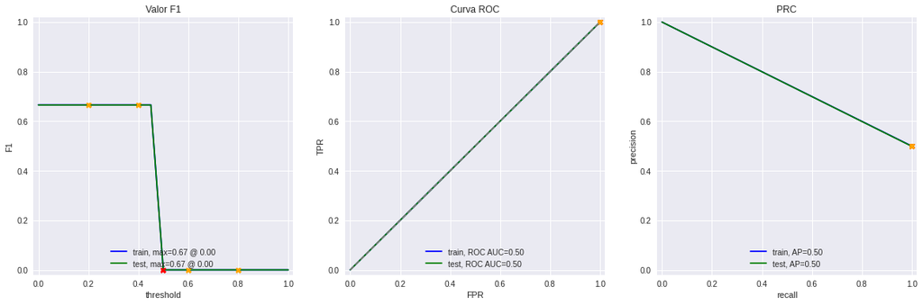

```python
precision_1,f1_1,aps_1,roc_1=evaluate_model(model_1, train_features, train_target, test_features, test_target)
```

Como era de esperarse, la precisión de este modelo es de un 50% (acierta solo el 50% de las veces) y el desempeño de este modelo es muy malo con un valor F1 igual a cero.

### Modelo 2 - NLTK, TF-IDF y Regresión Logistica

Para aplicar esta transformación usaré *TfidfVectorizer de sklearn*. Para una mejor vectorización, a TfidfVectorizer le pasaré como atributo las *stop_words* asociadas al inglés, las cuales no son mas que palabras vacías para inglés ("a", "the","in", "for", etc.) y que serán excluidas de la vectorización.

Finalmente entrenaremos usando un modelo de Regresión Logistica de sklearn y evaluaremos el desempeño usando la función `evaluate_model` creada anteriormente.

Nota1: Lematizar es reducir una palabra a su forma base o raíz, conocida como "lema".  
Nota2: Las *stop_words* ya estan definidas por la biblioteca NLTK y se llaman usando *nltk_stopwords*.

#### Construcción y entrenamiento del modelo

```python
import nltk

from sklearn.feature_extraction.text import TfidfVectorizer
from sklearn.linear_model import LogisticRegression

#from nltk.corpus import stopwords
from nltk.corpus import stopwords as nltk_stopwords
```

```python
from nltk.tokenize import word_tokenize
from nltk.stem import WordNetLemmatizer

lemmatizer  = WordNetLemmatizer()

def text_preprocessing_2(text):

    tokens = word_tokenize(text.lower())
    lemmas = [lemmatizer.lemmatize(token) for token in tokens]
    return ' '.join(tokens)
```

```python
#Lematizar todos el dataframe tarda unos minutos..
#spaCy tarda mas que NLTK
train_features_lemma=train_features.apply(text_preprocessing_2)
test_features_lemma=test_features.apply(text_preprocessing_2)
```

```python
#Junto las caracteristicas de entrenamiento y prueba para que tenga una matriz TF-IDF equivalente
corpus = pd.concat([train_features_lemma,test_features_lemma])

#Defino las palabras redundantes correspondientes al ingles
stop_words = set(nltk_stopwords.words('english'))
tfidf_vectorizer_2 = TfidfVectorizer(stop_words=stop_words)

#Aplico la transformación TF-IDF
tf_idf = tfidf_vectorizer_2.fit_transform(corpus)
print('El tamaño de la matriz TF-IDF:', tf_idf.shape)
```

```
El tamaño de la matriz TF-IDF: (47331, 97026)
```

```python
#Separamos los target y las caracteristicas (TF-IDF)
train_features_tf_idf =tf_idf[0:len(train_features)]
test_features_tf_idf =tf_idf[len(train_features):len(train_features)+len(test_features)]

#Definimos nuestro modelo (Regresion Logistica)
model_2 = LogisticRegression()
#Entrenamos
model_2.fit(train_features_tf_idf,train_target)
```

```
LogisticRegression()
```

#### Evaluación del modelo y conclusiones

```
          train  test
Accuracy   0.94  0.88
F1         0.94  0.88
APS        0.98  0.95
ROC AUC    0.98  0.95
```

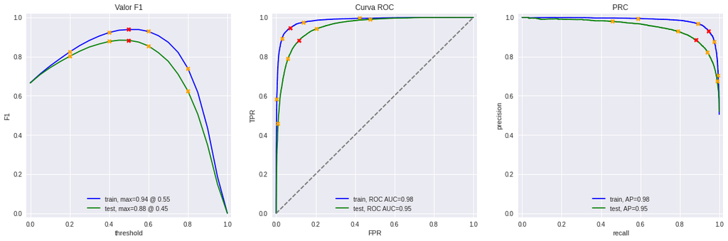

```python
precision_2,f1_2,aps_2,roc_2=evaluate_model(model_2, train_features_tf_idf, train_target, test_features_tf_idf, test_target)
```

El desempeño de este modelo es bastante bueno, obteniendo una precisión de un 88% y un valor F1 de 0.88 para los datos de prueba. Observamos tambien que este modelo muestra un leve sobreajuste (overfitting) dado que el probarlo con los datos de entrenamiento tiene un desempeño mayor a los nuevos datos de prueba.

Este modelo ya cumple con lo requerido (F1>0.85), sin embargo, evaluaremos el comportamiento de otros modelos a continuación.

### Modelo 3 - spaCy, TF-IDF y Regresión Logistica

Para este modelo, esta vez lematizaremos las reviews usando la libreria spaCy, para esto, crearé una función llamada `text_preprocessing_3`.

Una vez lematizadas las reviews, ponderaré la importancia de cada palabras calculando el TF-IDF (frecuencia de término - frecuencia inversa de documento) el cual transforma todas las palabras del dataset en un vector y asigna valores de relavancia para cada una.

Para aplicar esta transformación usaré *TfidfVectorizer de sklearn*. Para una mejor vectorización, a TfidfVectorizer le pasaré como atributo las *stop_words* asociadas al inglés, las cuales no son mas que palabras vacías para inglés ("a", "the","in", "for", etc.) y que serán excluidas de la vectorización.

Finalmente entrenaremos usando un modelo de Regresión Logistica de sklearn y evaluaremos el desempeño de este modelo usando la función `evaluate_model` creada anteriormente.

Nota1: Lematizar es reducir una palabra a su forma base o raíz, conocida como "lema".  
Nota2: Las *stop_words* ya estan definidas por la biblioteca NLTK y se llaman usando *nltk_stopwords*.

#### Construcción y entrenamiento del modelo

```python
import spacy
nlp = spacy.load('en_core_web_sm', disable=['parser', 'ner'])

def text_preprocessing_3(text):

    doc = nlp(text)
    #tokens = [token.lemma_ for token in doc if not token.is_stop]
    tokens = [token.lemma_ for token in doc]

    return ' '.join(tokens)
```

```python
#Lematizar todos el dataframe tarda unos minutos..
#spaCy tarda mas que NLTK
train_features_lemma=train_features.apply(text_preprocessing_3)
test_features_lemma=test_features.apply(text_preprocessing_3)
```

```python
#Junto las caracteristicas de entrenamiento y prueba para que tenga una matriz TF-IDF equivalente
corpus = pd.concat([train_features_lemma,test_features_lemma])

#Defino las palabras redundantes correspondientes al ingles
stop_words = set(nltk_stopwords.words('english'))
tfidf_vectorizer_3 = TfidfVectorizer(stop_words=stop_words)

#Aplico la transformación TF-IDF
tf_idf = tfidf_vectorizer_3.fit_transform(corpus)
print('El tamaño de la matriz TF-IDF:', tf_idf.shape)
```

```
El tamaño de la matriz TF-IDF: (47331, 82131)
```

```python
#Separamos los target y las caracteristicas (TF-IDF)
train_features_tf_idf =tf_idf[0:len(train_features)]
test_features_tf_idf =tf_idf[len(train_features):len(train_features)+len(test_features)]

#Definimos nuestro modelo (Regresion Logistica)
model_3 = LogisticRegression()

#Entrenamos
model_3.fit(train_features_tf_idf,train_target)
```

```
LogisticRegression()
```

#### Evaluación del modelo y conclusiones

```
          train  test
Accuracy   0.93  0.88
F1         0.93  0.88
APS        0.98  0.95
ROC AUC    0.98  0.95
```

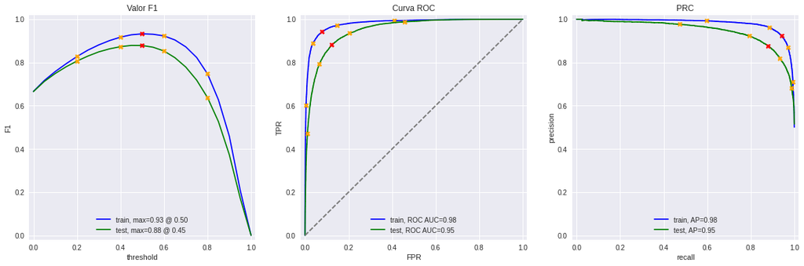

```python
precision_3,f1_3,aps_3,roc_3=evaluate_model(model_3, train_features_tf_idf, train_target, test_features_tf_idf, test_target)
```

El desempeño de este modelo es prácticamente identico al modelo 2, obteniendo una precisión de un 88% y un valor F1 de 0.88 para los datos de prueba. Observamos tambien que este modelo muestra un leve sobreajuste (overfitting) el cual es menor que el sobrejuste del modelo 2.

Este modelo ya cumple con lo requerido (F1>0.85), sin embargo, evaluaremos el comportamiento de otros modelos.

### Modelo 4 - spaCy, TF-IDF y LGBMClassifier

El modelo 4 usará la misma data lematizada con spaCy y vectorizada con TfidfVectorizer que su uso para entrenar el modelo 3. Sin embargo, para el modelo 4, esta vez entrenaremos un modelo LGBMClassifier para realizar la tarea de clasificación.

Al igual que los modelos anteriores, evaluaremos el desempeño de este modelo usando la función `evaluate_model`.

#### Construcción y entrenamiento del modelo

```python
from lightgbm import LGBMClassifier
```

```python
#Definimos el modelo
model_4 = LGBMClassifier()

#Entrenamos
model_4.fit(train_features_tf_idf,train_target)
```

```
LGBMClassifier()
```

#### Evaluación del modelo y conclusiones

```
          train  test
Accuracy   0.91  0.86
F1         0.91  0.86
APS        0.97  0.93
ROC AUC    0.97  0.94
```

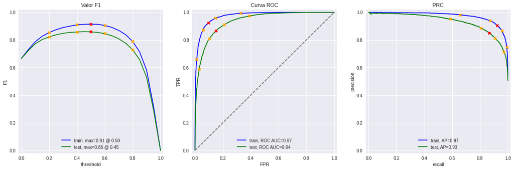

```python
precision_4,f1_4,aps_4,roc_4=evaluate_model(model_4, train_features_tf_idf, train_target, test_features_tf_idf, test_target)
```

El desempeño de este modelo es bastante bueno, pero inferior a los modelos 2 y 3, obteniendo una precisión de un 86% y un valor F1 de 0.86 para los datos de prueba. Observamos tambien que este modelo muestra un leve sobreajuste (overfitting) el cual es menor que el mostrado por los modelos 2 y 3

Este modelo ya cumple con lo requerido (F1>0.85), sin embargo, evaluaremos el comportamiento de un último modelo.

### Modelo 9 - BERT + Regresión Logistica

Finalmente, nuestro último modelo utilizará una herramienta más avanzada llamada BERT, el cual es un modelo de red neuronal creado para la representación del lenguaje y que transforma palabras en vectores o "embeddings". Al procesar palabras, BERT considera tanto las palabras vecinas inmediatas como las palabras más lejanas. Esto permite que BERT produzca vectores precisos con respecto al significado natural de las palabras. Además, aprende a averiguar si las palabras del enunciado están o no relacionadas.

El problema de BERT es que para calcular los "embeddings" demanda una gran cantidad de procesamiento, lo cual lleva mucho tiempo cuando se ejecuta en una CPU. Para abordar este problema, para el cálculo de los "embeddings" utilizaré los servidores de Google Colab que proporcionan acceso a tarjetas gráficas (GPU), las cuales son hardware especializado para acelerar el cálculo de modelos de redes neuronales como BERT.

Una vez obtenido los "embeddings", entrenaré un modelo de Regresión Logistica (el cual mostró un mejor desempeño en los modelos anteriores) y evaluraremos los resultados.

Nota: BERT no necesita que las palabras sean lematizadas para vectorizar las palabras.

#### Vectorización de las reviews de entrenamiento

```python
import torch
import transformers
```

```python
tokenizer = transformers.BertTokenizer.from_pretrained('bert-base-uncased')
config = transformers.BertConfig.from_pretrained('bert-base-uncased')
model = transformers.BertModel.from_pretrained('bert-base-uncased')
```

[output not shown]

```python
def BERT_text_to_embeddings(texts, max_length=512, batch_size=100, force_device=None, disable_progress_bar=False):

    ids_list = []
    attention_mask_list = []

    # texto al id de relleno de tokens junto con sus máscaras de atención

    for input_text in texts:
        ids = tokenizer.encode(input_text.lower(), add_special_tokens=True, truncation=True, max_length=max_length)
        padded = np.array(ids + [0]*(max_length - len(ids)))
        attention_mask = np.where(padded != 0, 1, 0)
        ids_list.append(padded)
        attention_mask_list.append(attention_mask)



    # <escribe tu código aquí para crear ids_list y attention_mask_list>

    if force_device is not None:
        device = torch.device(force_device)
    else:
        device = torch.device('cuda' if torch.cuda.is_available() else 'cpu')

    model.to(device)
    if not disable_progress_bar:
        print(f'Uso del dispositivo {device}.')

    # obtener insertados en lotes

    embeddings = []

    for i in tqdm(range(math.ceil(len(ids_list)/batch_size)), disable=disable_progress_bar):

        ids_batch = torch.LongTensor(ids_list[batch_size*i:batch_size*(i+1)]).to(device)
        # Creamos attention_mask_batch
        attention_mask_batch = torch.LongTensor(attention_mask_list[batch_size*i:batch_size*(i+1)]).to(device)

        with torch.no_grad():
            model.eval()
            batch_embeddings = model(input_ids=ids_batch, attention_mask=attention_mask_batch)
        embeddings.append(batch_embeddings[0][:,0,:].detach().cpu().numpy())

    return np.concatenate(embeddings)
```

```python
#Cargamos los embeddings anteriormente calculados, si no se encuentra el archivo, se calculan
#Nota: Dado el tiempo que tarda calcular los embeddings, usé Google Colab para calcularlos mas rápidamente
#luego subi el archivo al entorno
#El link al archivo en Drive es: https://drive.google.com/file/d/1PubZ697w1NFnBXdLZ56tfaAEAAvD8lev/view?usp=drive_link
import os
if os.path.exists('features_9.npz'):
    print("Embeddings encontrados!")

    with np.load('features_9.npz') as data:
        train_features_9 = data['train_features_9']
        test_features_9 = data['test_features_9']

else:
    print("Calculando embeddings.....")
    #¡Atención! La ejecución de BERT para miles de textos puede llevar mucho tiempo en la CPU, al menos varias horas
    train_features_9 = BERT_text_to_embeddings(df_reviews_train['review_norm'], force_device='cpu')
    test_features_9 = BERT_text_to_embeddings(df_reviews_test['review_norm'], force_device='cpu')

    #Guardamos los embeddings
    np.savez_compressed('features_9.npz', train_features_9=train_features_9, test_features_9=test_features_9)
```

```
Embeddings encontrados!
```

```python
print(df_reviews_train['review_norm'].shape)
print(train_features_9.shape)
print(train_target.shape)
```

```
(23796,)
(23796, 768)
(23796,)
```

#### Construcción y entrenamiento del modelo

```python
#Definimos el modelo
model_9 = LogisticRegression()

#Entrenamos
model_9.fit(train_features_9,df_reviews_train['pos'])
```

```
LogisticRegression()
```

#### Evaluación del modelo y conclusiones

```
          train  test
Accuracy   0.87  0.86
F1         0.87  0.86
APS        0.94  0.94
ROC AUC    0.94  0.94
```

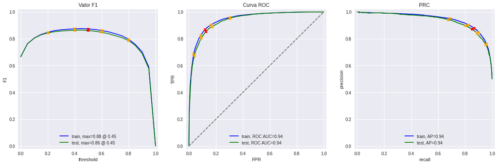

```python
precision_9,f1_9,aps_9,roc_9=evaluate_model(model_9, train_features_9, df_reviews_train['pos'],test_features_9, df_reviews_test['pos'])
```

El desempeño de este modelo tambien fue bastante bueno, equivalente al modelo 4 e inferior a los modelos 2 y 3, obteniendo una precisión de un 86% y un valor F1 de 0.86 para los datos de prueba. Sin embargo, vemos que este modelo muestra un casi nulo sobreajuste (overfitting), lo cual indica que el modelo es MUY bueno generalizando y que sus predicciones aún seguiran siendo confiables incluso frente a reseñas completamente diferentes a las del set de entrenamiento.

Este modelo tambien cumple con lo requerido (F1>0.85).

## Mis reseñas

En este punto, probaré el desempeño de los modelos anteriores usando reseñas aleatorias en inglés (dado que los modelos se entrenaron en inglés) y evaluaremos el desempeño de estos con mi "subjetivo" criterio humano.

Nota: en vez de usar `model.predict` el cual entrega una predicción concreta (0 o 1), usaré `model.predict_proba` el cual arroja la probabilidad de que la reseña sea positiva.

```python
# puedes eliminar por completo estas reseñas y probar tus modelos en tus propias reseñas; las que se muestran a continuación son solo ejemplos

my_reviews = pd.DataFrame([
    'It\'s the worst movie I\'ve ever seen, a real waste of time.',
    'the best movie of all time, the best cast and the story is captivating.',
    'I did not simply like it, not my kind of movie.',
    'Well, I was bored and felt asleep in the middle of the movie.',
    'I was really fascinated with the movie',
    'Even the actors looked really old and disinterested, and they got paid to be in the movie. What a soulless cash grab.',
    'I didn\'t expect the reboot to be so good! Writers really cared about the source material',
    'The movie had its upsides and downsides, but I feel like overall it\'s a decent flick. I could see myself going to see it again.',
    'What a rotten attempt at a comedy. Not a single joke lands, everyone acts annoying and loud, even kids won\'t like this!',
    'Launching on Netflix was a brave move & I really appreciate being able to binge on episode after episode, of this exciting intelligent new drama.'
], columns=['review'])

"""
Significado de las reseñas en español:
my_reviews = pd.DataFrame([
    'La peor pelicula que jamas he visto, una verdadera perdida de tiempo'
    'La mejor pelicula de todos los tiempos, el mejor reparto y la historia es cautivadora.'
    'Simplemente no me gustó, no es mi tipo de película.',
    'Bueno, estaba aburrido y me quedé dormido a media película.',
    'Estaba realmente fascinada con la película',
    'Hasta los actores parecían muy viejos y desinteresados, y les pagaron por estar en la película. Qué robo tan desalmado.',
    '¡No esperaba que el relanzamiento fuera tan bueno! Los escritores realmente se preocuparon por el material original',
    'La película tuvo sus altibajos, pero siento que, en general, es una película decente. Sí la volvería a ver',
    'Qué pésimo intento de comedia. Ni una sola broma tiene sentido, todos actúan de forma irritante y ruidosa, ¡ni siquiera a los niños les gustará esto!',
    'Fue muy valiente el lanzamiento en Netflix y realmente aprecio poder seguir viendo episodio tras episodio de este nuevo drama tan emocionante e inteligente.'
], columns=['review'])
"""

my_reviews['review_norm'] = my_reviews['review'].apply(clear_text)
my_reviews
```

|  | review | review_norm |
| --- | --- | --- |
| 0 | It's the worst movie I've ever seen, a real wa... | it's the worst movie i've ever seen a real was... |
| 1 | the best movie of all time, the best cast and ... | the best movie of all time the best cast and t... |
| 2 | I did not simply like it, not my kind of movie. | i did not simply like it not my kind of movie |
| 3 | Well, I was bored and felt asleep in the middl... | well i was bored and felt asleep in the middle... |
| 4 | I was really fascinated with the movie | i was really fascinated with the movie |
| 5 | Even the actors looked really old and disinter... | even the actors looked really old and disinter... |
| 6 | I didn't expect the reboot to be so good! Writ... | i didn't expect the reboot to be so good write... |
| 7 | The movie had its upsides and downsides, but I... | the movie had its upsides and downsides but i ... |
| 8 | What a rotten attempt at a comedy. Not a singl... | what a rotten attempt at a comedy not a single... |
| 9 | Launching on Netflix was a brave move & I real... | launching on netflix was a brave move i really... |

### Modelo 2

```python
texts = my_reviews['review_norm']

my_reviews_pred_prob = model_2.predict_proba(tfidf_vectorizer_2.transform(texts))[:, 1]

for i, review in enumerate(texts.str.slice(0, 100)):
    print(f'{my_reviews_pred_prob[i]:.2f}:  {review}')
```

```
0.00:  it's the worst movie i've ever seen a real waste of time
0.98:  the best movie of all time the best cast and the story is captivating
0.14:  i did not simply like it not my kind of movie
0.16:  well i was bored and felt asleep in the middle of the movie
0.54:  i was really fascinated with the movie
0.12:  even the actors looked really old and disinterested and they got paid to be in the movie what a soul
0.31:  i didn't expect the reboot to be so good writers really cared about the source material
0.46:  the movie had its upsides and downsides but i feel like overall it's a decent flick i could see myse
0.04:  what a rotten attempt at a comedy not a single joke lands everyone acts annoying and loud even kids
0.83:  launching on netflix was a brave move i really appreciate being able to binge on episode after episo
```

Este modelo muestra consistencia respecto a sus respuestas, asignando 0% a la reseña 1 y casi un 100% a la reseña 2.  
En particular llama mi atención el porcentaje que atribuye a las reseñas 5 y 7.

*Reseña 5: 'Estaba realmente fascinada con la película'*  
*Reseña 7: '¡No esperaba que el relanzamiento fuera tan bueno! Los escritores realmente se preocuparon por el material original'*

que solo les atribute un 54% y un 31% respectivamente. (para mi debería ser un porcentaje mayor)

### Modelo 3

```python
texts = my_reviews['review_norm']

my_reviews_pred_prob = model_3.predict_proba(tfidf_vectorizer_3.transform(texts.apply(lambda x: text_preprocessing_3(x))))[:, 1]

for i, review in enumerate(texts.str.slice(0, 100)):
    print(f'{my_reviews_pred_prob[i]:.2f}:  {review}')
```

```
0.00:  it's the worst movie i've ever seen a real waste of time
0.96:  the best movie of all time the best cast and the story is captivating
0.20:  i did not simply like it not my kind of movie
0.12:  well i was bored and felt asleep in the middle of the movie
0.49:  i was really fascinated with the movie
0.10:  even the actors looked really old and disinterested and they got paid to be in the movie what a soul
0.28:  i didn't expect the reboot to be so good writers really cared about the source material
0.50:  the movie had its upsides and downsides but i feel like overall it's a decent flick i could see myse
0.03:  what a rotten attempt at a comedy not a single joke lands everyone acts annoying and loud even kids
0.92:  launching on netflix was a brave move i really appreciate being able to binge on episode after episo
```

Este modelo tambien muestra consistencia repecto a sus respuestas, asignando 0% de la reseña 1 y casi un 100% a la reseña 2.  
Una vez mas llama mi atención el porcentaje que atribuye a las reseñas 5 y 7.

*Reseña 5: 'Estaba realmente fascinada con la película'*  
*Reseña 7: '¡No esperaba que el relanzamiento fuera tan bueno! Los escritores realmente se preocuparon por el material original'*

que solo les atribute un 49% y un 28% respectivamente. (para mi debería ser un porcentaje mayor)

### Modelo 4

```python
texts = my_reviews['review_norm']

tfidf_vectorizer_4 = tfidf_vectorizer_3
my_reviews_pred_prob = model_4.predict_proba(tfidf_vectorizer_4.transform(texts.apply(lambda x: text_preprocessing_3(x))))[:, 1]

for i, review in enumerate(texts.str.slice(0, 100)):
    print(f'{my_reviews_pred_prob[i]:.2f}:  {review}')
```

```
0.05:  it's the worst movie i've ever seen a real waste of time
0.83:  the best movie of all time the best cast and the story is captivating
0.53:  i did not simply like it not my kind of movie
0.41:  well i was bored and felt asleep in the middle of the movie
0.59:  i was really fascinated with the movie
0.36:  even the actors looked really old and disinterested and they got paid to be in the movie what a soul
0.70:  i didn't expect the reboot to be so good writers really cared about the source material
0.68:  the movie had its upsides and downsides but i feel like overall it's a decent flick i could see myse
0.26:  what a rotten attempt at a comedy not a single joke lands everyone acts annoying and loud even kids
0.81:  launching on netflix was a brave move i really appreciate being able to binge on episode after episo
```

Al igual que los modelos anteriores, este modelo tambien es consistente, pero se nota que es levemente inferior a los 2 anteriores.

### Modelo 9

```python
texts = my_reviews['review_norm']

my_reviews_features_9 = BERT_text_to_embeddings(texts, disable_progress_bar=True)

my_reviews_pred_prob = model_9.predict_proba(my_reviews_features_9)[:, 1]

for i, review in enumerate(texts.str.slice(0, 100)):
    print(f'{my_reviews_pred_prob[i]:.2f}:  {review}')
```

```
0.02:  it's the worst movie i've ever seen a real waste of time
1.00:  the best movie of all time the best cast and the story is captivating
0.34:  i did not simply like it not my kind of movie
0.01:  well i was bored and felt asleep in the middle of the movie
0.99:  i was really fascinated with the movie
0.00:  even the actors looked really old and disinterested and they got paid to be in the movie what a soul
0.22:  i didn't expect the reboot to be so good writers really cared about the source material
0.97:  the movie had its upsides and downsides but i feel like overall it's a decent flick i could see myse
0.07:  what a rotten attempt at a comedy not a single joke lands everyone acts annoying and loud even kids
0.95:  launching on netflix was a brave move i really appreciate being able to binge on episode after episo
```

Por último, si bien, como vimos anteriormente, el desempeño de este modelo teoricamente es inferior a los modelos 2 y 3, desde mi humilde opinión, para mi, la predicción de BERT generaliza mejor. Me parece que este modelo "duda" menos al momento de determinar la probabilidad de una review, asignando probabilidades con mayor "seguridad" al momento de determinar el sentimiento de una reseña. En particular llama mi atención la reseña 5.

*Reseña 5: 'Estaba realmente fascinada con la película'*

Reseña que los otros modelos no evaluaron del todo bien, este le da un probabilidad de casi un 100% (de que sea positiva).

## Conclusiones

```python
resumen = {
    'Modelo': ['Modelo Dummy', 'Modelo 2', 'Modelo 3','Modelo 4','Modelo 9'],
    'Precisión':[precision_1,precision_2,precision_3,precision_4,precision_9],
    'F1':[f1_1,f1_2,f1_3,f1_4,f1_9],
    'APS':[aps_1,aps_2,aps_3,aps_4,aps_9],
    'ROC AUC':[roc_1,roc_2,roc_3,roc_4,roc_9]
}
#Utilizo round para aproximar a un solo digito
resumen = pd.DataFrame(resumen).round(2)
resumen
```

|  | Modelo | Precisión | F1 | APS | ROC AUC |
| --- | --- | --- | --- | --- | --- |
| 0 | Modelo Dummy | 0.50 | 0.00 | 0.50 | 0.50 |
| 1 | Modelo 2 | 0.88 | 0.88 | 0.95 | 0.95 |
| 2 | Modelo 3 | 0.88 | 0.88 | 0.95 | 0.95 |
| 3 | Modelo 4 | 0.86 | 0.86 | 0.93 | 0.94 |
| 4 | Modelo 9 | 0.86 | 0.86 | 0.94 | 0.94 |

Teniendo en cuenta que los modelos 2 y 3 son los que mejores métricas presentan, son los ideales para esta tarea de clasificación, tanto por sus metricas como por su simplicidad en comparación con el resto de modelos.